# Week 5 Exercises

Read the file timeuse_tidy.rds with `readRDS()`. The file contains the dataset that we tidied in the exercise session: records of daily time use from participants over multiple days. Note that since the data has been stored as rds (R-specific format), column types and factor levels are as we left them, and don’t need to be re-corrected.

# Exercise 1

#### 1.1

Create a new variable that contains combined activity classes: “Work or school” (Work, Business, Education), “Free time” (Shopping, Social / Leisure, Home, Vacation), and “Other”.

Calculate the mean time spent on each of the combined activity classes, grouped by **weekday, participant ID, and occ_full_time**.

| weekday | indivID | occ_full_time | activity3 | time_spent | n |
| --- | --- | --- | --- | --- | --- |
| Mon | 1013302 | 0 | Work or school | 0.0000000 | 3 |
| Mon | 1013302 | 0 | Free time | 355.5000000 | 4 |
| Mon | 1013302 | 0 | Other | 3.6000000 | 5 |
| Mon | 1056237 | 1 | Work or school | 0.0000000 | 3 |
| Mon | 1056237 | 1 | Free time | 360.0000000 | 4 |
| Mon | 1056237 | 1 | Other | 0.0000000 | 5 |
| Mon | 1103940 | 1 | Work or school | 68.1666667 | 6 |
| Mon | 1103940 | 1 | Free time | 284.6250000 | 8 |
| Mon | 1103940 | 1 | Other | 19.4000000 | 10 |
| Mon | 1198262 | 1 | Work or school | 0.0000000 | 3 |

[output cut: 990 more lines]

#### 1.2

Visualise the means you calculated.

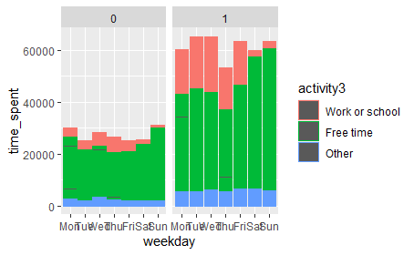

# Exercise 2

#### 2.1

What is computed in the code chunk below - what do the numbers tell you?

Can you think of another way to calculate the same thing?

| date | n |
| --- | --- |
| 2016-10-14 | 6 |
| 2016-10-15 | 11 |
| 2016-10-16 | 10 |
| 2016-10-17 | 10 |
| 2016-10-18 | 14 |
| 2016-10-19 | 16 |
| 2016-10-20 | 11 |
| 2016-10-21 | 11 |
| 2016-10-22 | 17 |
| 2016-10-23 | 18 |

[output cut: 63 more lines]

#### 2.2

Plot the numbers from above (use points, lines, or whatever you think is suitable).

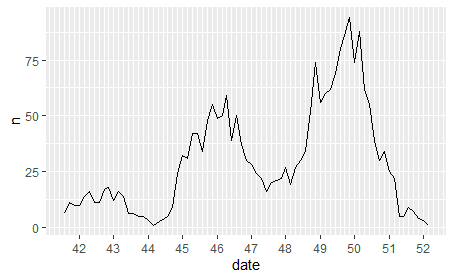

# Exercise 3

#### 3.1

Count the **total number of participants** in the data.

| n |
| --- |
| 356 |

#### 3.2

For each participant, count the **number of separate days** that they recorded their time use on.

| indivID | n |
| --- | --- |
| 1013302 | 10 |
| 1056237 | 7 |
| 1103940 | 7 |
| 118068 | 7 |
| 1198262 | 5 |
| 1202035 | 5 |
| 121881 | 7 |
| 1226238 | 1 |
| 1292043 | 4 |
| 1326897 | 4 |

[output cut: 346 more lines]

# Exercise 4

Explain step by step what happens in the code chunk below, and what the final figure represents.

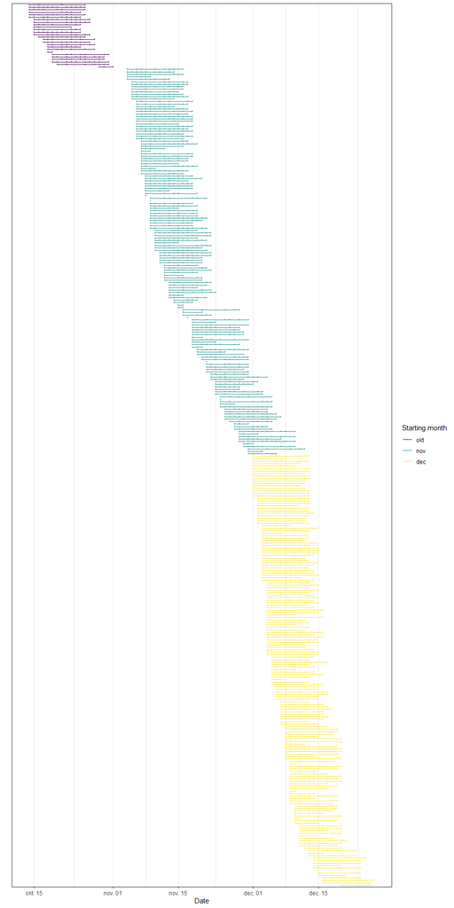